# pertemuan4

Hakim Zoelva Mahesa

2023-09-21

## White Noise

Pembangkitan data berpola AR, MA, ARMA, dan banyak proses deret waktu lainnya diawali pembangkitan *white noise*. *White noise* merupakan sederet nilai dari peubah bebas stokastik identik. *White noise* dibangkitkan dari suatu peubah acak, umumnya peubah acak normal.

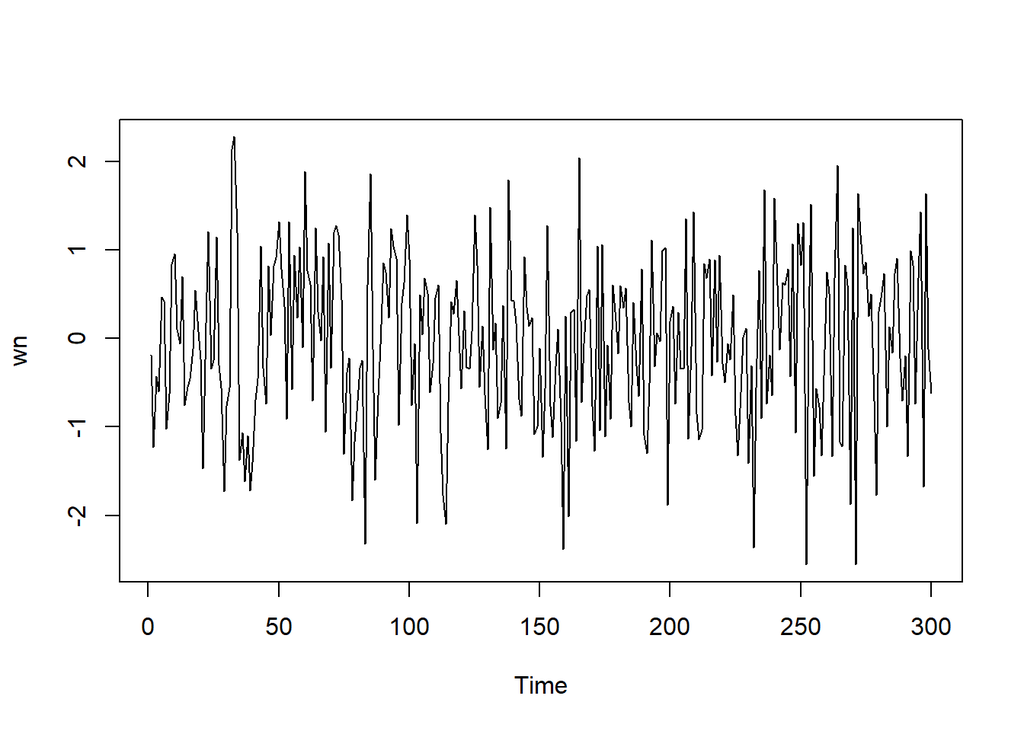

```r
set.seed(039)
wn <- rnorm(300)
ts.plot(wn)
```

## Pembangkitan Proses MA(2)

```r
ma <- wn[c(1,2)]
ma <-wn
```

```r
for(i in 3:300){
   ma[i] <- wn[i] + 0.4 * wn[i - 1]+0.6*wn[i-2]
}
ma
```

```
##   [1] -0.185565721 -1.229242670 -1.030239426 -1.504408702 -0.027390976
##   [6]  0.250979263 -0.572602353 -0.778154446 -0.024980319  0.922941446
##  [11]  0.991081996  0.558873885  0.742351779 -0.509354087 -0.425284892
##  [16] -1.125808598 -0.625772420  0.228405155  0.228802787  0.128080981
##  [21] -1.517490344 -0.550906818  0.397665182  0.250318499  0.340574169
##  [26]  0.848273324  0.012133903  0.015006148 -2.130523800 -1.790134466
##  [31] -1.899572436  1.453462275  2.801524831  3.390563425  0.473565865
##  [36] -0.896248364 -2.863692581 -2.382552185 -3.122498713 -2.744915690
##  [41] -2.284507637 -1.573338400  0.449672376 -0.185589565 -0.237850834
##  [46]  0.330349468 -0.072036000  1.328664432  1.263418825  2.179341061
##  [51]  1.861054095  1.472306289 -0.292934748  1.178431017 -0.589165678
##  [56]  1.503623098  0.268930081  1.690355491  0.455944426  2.464418616
##  [61]  1.465837416  2.055063914  0.008684878  1.340732807  0.380745851
##  [66]  0.847027681  1.094233154 -0.701282748  1.209507475 -0.537855720
##  [71]  1.713890464  1.552644718  2.404522415  1.679402634 -0.423067193
```

[output cut: 45 more lines]

Selain menggunakan cara di atas, pembangkitan proses MA(2) dapat dilakukan dengan fungsi `arima.sim()` sebagai berikut.

```r
set.seed(039)
ma2 <- arima.sim(list(order=c(0,0,2), ma=c(0.4,0.6)), n=300)
ma2
```

```
## Time Series:
## Start = 1
## End = 300
## Frequency = 1
##   [1] -1.030239426 -1.504408702 -0.027390976  0.250979263 -0.572602353
##   [6] -0.778154446 -0.024980319  0.922941446  0.991081996  0.558873885
##  [11]  0.742351779 -0.509354087 -0.425284892 -1.125808598 -0.625772420
##  [16]  0.228405155  0.228802787  0.128080981 -1.517490344 -0.550906818
##  [21]  0.397665182  0.250318499  0.340574169  0.848273324  0.012133903
##  [26]  0.015006148 -2.130523800 -1.790134466 -1.899572436  1.453462275
##  [31]  2.801524831  3.390563425  0.473565865 -0.896248364 -2.863692581
##  [36] -2.382552185 -3.122498713 -2.744915690 -2.284507637 -1.573338400
##  [41]  0.449672376 -0.185589565 -0.237850834  0.330349468 -0.072036000
##  [46]  1.328664432  1.263418825  2.179341061  1.861054095  1.472306289
##  [51] -0.292934748  1.178431017 -0.589165678  1.503623098  0.268930081
```

[output cut: 49 more lines]

## Karakteristik MA(2)

### Plot Time Series

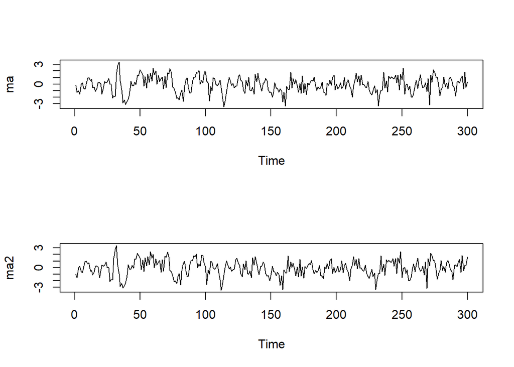

```r
par(mfrow = c(2, 1))
ts.plot(ma)
ts.plot(ma2)
```

Berdasarkan plot time series, terlihat bahwa data MA(2) yang dibangkitkan stasioner dalam rataan

### Plot ACF

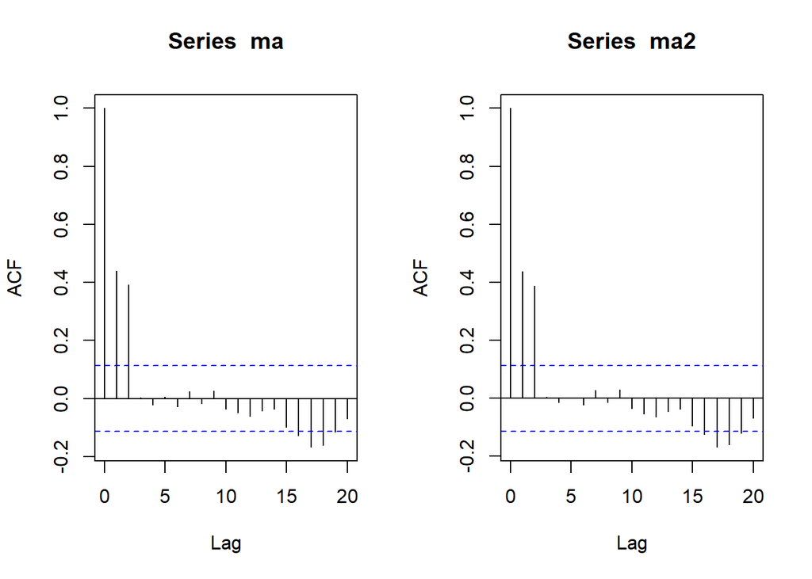

```r
par(mfrow = c(1,2))
acf(ma,lag.max = 20)
acf(ma2,lag.max = 20)
```

Berdasarkan plot AFC tersebut, diketahui bahwa dalam model tersebut terdapat autokorelasi

### Plot PACF

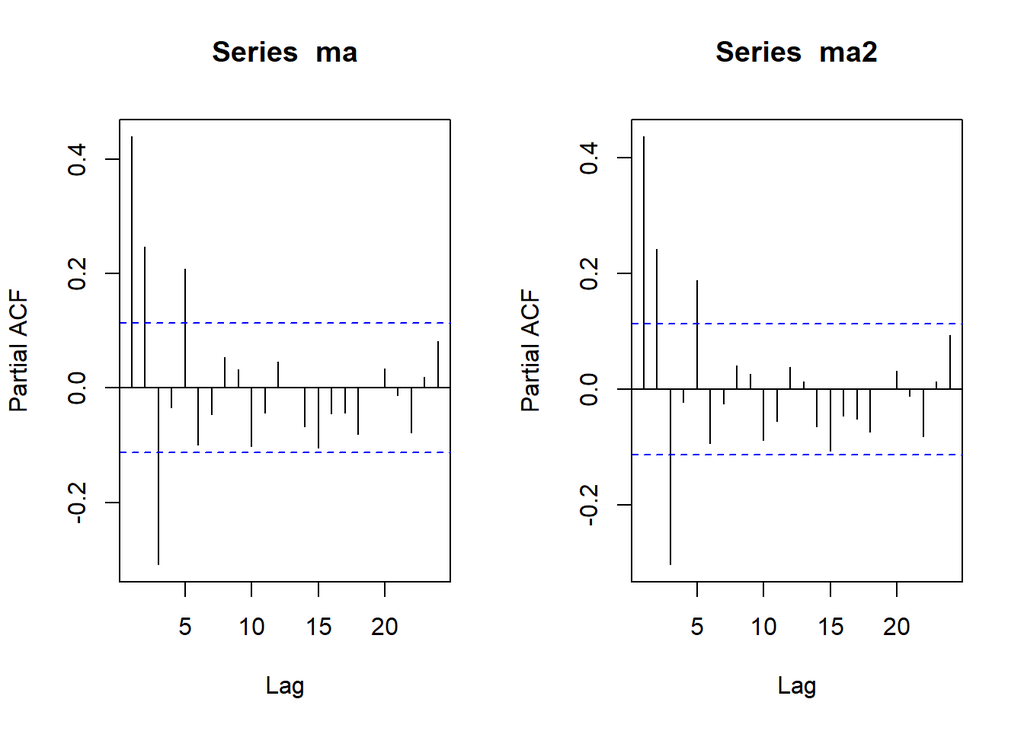

```r
par(mfrow = c(1,2))
pacf(ma)
pacf(ma2)
```

Berdasarkan plot PACF tersebut, terlihat bahwa plot PACF cenderung *tails off* dan membentuk gelombang sinus

### Plot EACF

```r
TSA::eacf(ma)
```

```
## AR/MA
##   0 1 2 3 4 5 6 7 8 9 10 11 12 13
## 0 x x o o o o o o o o o  o  o  o
## 1 x x o o o o o o o o o  o  o  o
## 2 x x o x o o o o o o o  o  o  o
## 3 o x o x x o o o o o o  o  o  o
## 4 x x x o o x o o o o o  o  o  o
## 5 x x x o o o x o o o o  o  o  o
## 6 x x o o o o x o o o o  o  o  o
## 7 x x o o o o o o o o o  o  o  o
```

```r
TSA::eacf(ma2)
```

```
## AR/MA
##   0 1 2 3 4 5 6 7 8 9 10 11 12 13
## 0 x x o o o o o o o o o  o  o  o
## 1 x x o o o o o o o o o  o  o  o
## 2 x x x x o o o o o o o  o  o  o
## 3 o x o x x o o o o o o  o  o  o
## 4 x x x o o o o o o o o  o  o  o
## 5 x x o x x o o o o o o  o  o  o
## 6 x x o x x o o o o o o  o  o  o
## 7 x x o o o o o o o o o  o  o  o
```

Berdasarkan pola segitiga nol pada plot EACF, terlihat bahwa segitiga nol berada pada ordo AR(0) dan ordo MA(2)

### Scatterplot Antar Lag

#### Korelasi antara $Y_t$ dengan $Y_{t-1}$

```r
#Yt
yt_ma <- ma[-1]
head(yt_ma)
```

```
## [1] -1.22924267 -1.03023943 -1.50440870 -0.02739098  0.25097926 -0.57260235
```

```r
#Yt-1
yt_1_ma <- ma[-300]
head(yt_1_ma)
```

```
## [1] -0.18556572 -1.22924267 -1.03023943 -1.50440870 -0.02739098  0.25097926
```

```r
#Yt
yt_ma2 <- ma2[-1]
head(yt_ma2)
```

```
## [1] -1.50440870 -0.02739098  0.25097926 -0.57260235 -0.77815445 -0.02498032
```

```r
#Yt-1
yt_1_ma2 <- ma2[-300]
head(yt_1_ma2)
```

```
## [1] -1.03023943 -1.50440870 -0.02739098  0.25097926 -0.57260235 -0.77815445
```

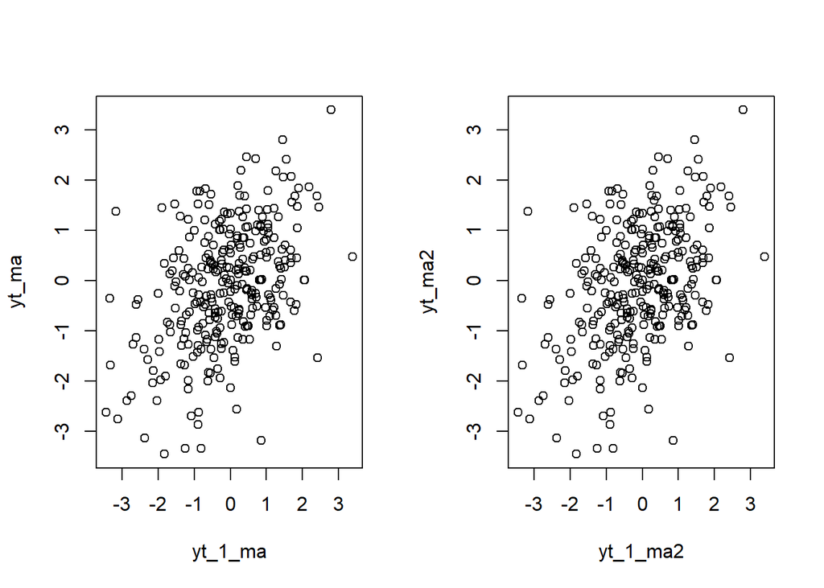

```r
par(mfrow = c(1,2))
plot(y=yt_ma,x=yt_1_ma)
plot(y=yt_ma2,x=yt_1_ma2)
```

```r
cor(yt_ma,yt_1_ma)
```

```
## [1] 0.4393294
```

```r
cor(yt_ma2,yt_1_ma2)
```

```
## [1] 0.43864
```

#### Korelasi antara $Y_t$ dengan $Y_{t-2}$

```r
#Yt
yt2_ma <- ma[-c(1,2)]
head(yt2_ma)
```

```
## [1] -1.03023943 -1.50440870 -0.02739098  0.25097926 -0.57260235 -0.77815445
```

```r
#Yt-2
yt_2_ma <- ma[-c(299,300)]
head(yt_2_ma)
```

```
## [1] -0.18556572 -1.22924267 -1.03023943 -1.50440870 -0.02739098  0.25097926
```

```r
#Yt
yt2_ma2 <- ma2[-c(1,2)]
head(yt2_ma2)
```

```
## [1] -0.02739098  0.25097926 -0.57260235 -0.77815445 -0.02498032  0.92294145
```

```r
#Yt-2
yt_2_ma2 <- ma2[-c(299,300)]
head(yt_2_ma2)
```

```
## [1] -1.03023943 -1.50440870 -0.02739098  0.25097926 -0.57260235 -0.77815445
```

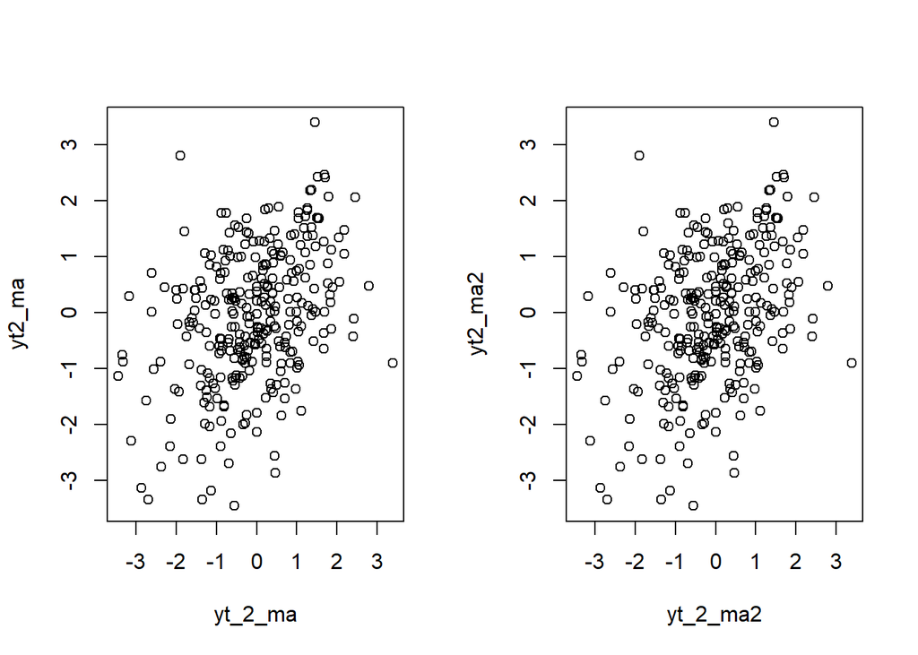

```r
par(mfrow = c(1,2))
plot(y=yt2_ma,x=yt_2_ma)
plot(y=yt2_ma2,x=yt_2_ma2)
```

```r
cor(yt2_ma,yt_2_ma)
```

```
## [1] 0.3922918
```

```r
cor(yt2_ma2,yt_2_ma2)
```

```
## [1] 0.3898946
```

#### Korelasi antara $Y_t$ dengan $Y_{t-3}$

```r
#Yt
yt3_ma <- ma[-c(1,2,3)]
head(yt3_ma)
```

```
## [1] -1.50440870 -0.02739098  0.25097926 -0.57260235 -0.77815445 -0.02498032
```

```r
#Yt-3
yt_3_ma <- ma[-c(298,299,300)]
head(yt_3_ma)
```

```
## [1] -0.18556572 -1.22924267 -1.03023943 -1.50440870 -0.02739098  0.25097926
```

```r
#Yt
yt3_ma2 <- ma2[-c(1,2,3)]
head(yt3_ma2)
```

```
## [1]  0.25097926 -0.57260235 -0.77815445 -0.02498032  0.92294145  0.99108200
```

```r
#Yt-3
yt_3_ma2 <- ma2[-c(298,299,300)]
head(yt_3_ma2)
```

```
## [1] -1.03023943 -1.50440870 -0.02739098  0.25097926 -0.57260235 -0.77815445
```

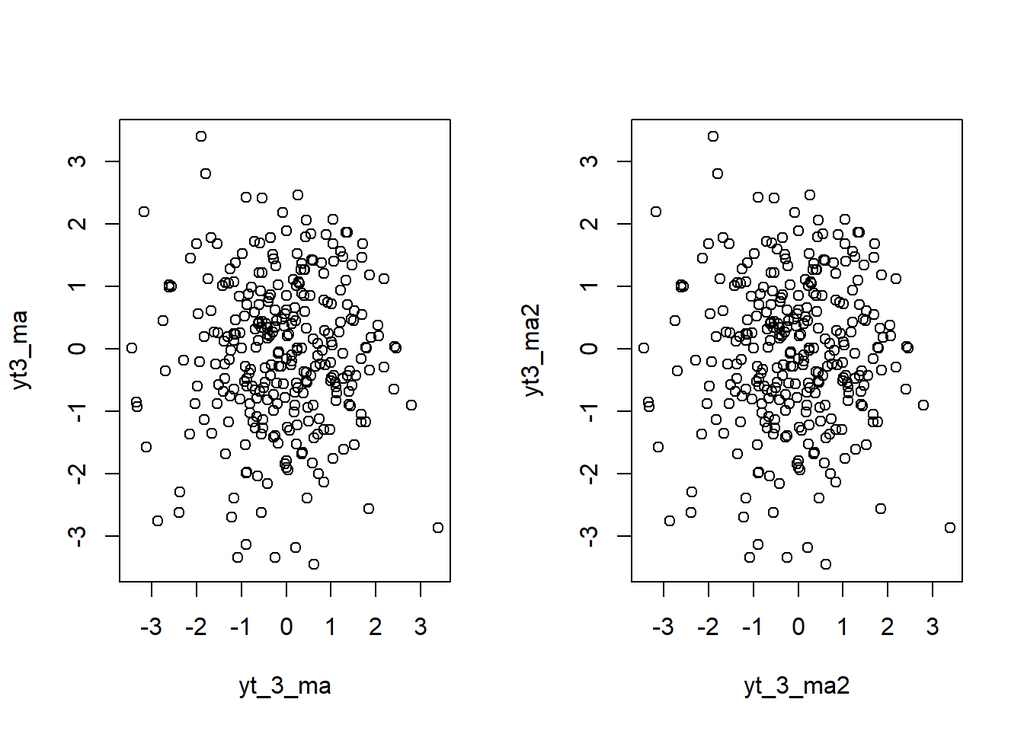

```r
par(mfrow = c(1,2))
plot(y=yt3_ma,x=yt_3_ma)
plot(y=yt3_ma2,x=yt_3_ma2)
```

```r
cor(yt3_ma,yt_3_ma)
```

```
## [1] 0.003811504
```

```r
cor(yt3_ma2,yt_3_ma2)
```

```
## [1] 0.003883948
```

## Proses AR (2)

## Pembangkitan Proses AR

Akan dicoba membangkitkan proses AR (2) dengan $\phi_1 = 0.5$ dan $\phi_2 = 0.2$ sebanyak 300 observasi dan $c=0$.

```r
set.seed(039)
```

```r
n<-length(wn)
n
```

```
## [1] 300
```

```r
ar <- c(1:n)
for (i in 3:n) {ar[i]<-wn[i]+0.5*ar[i-1]+0.2*ar[i-2]}
ar
```

```
##   [1]  1.000000000  2.000000000  0.772797074  0.190416608  0.717091270
##   [6]  0.818267956 -0.469099852 -0.693373347  0.396495093  1.021199836
##  [11]  0.694129107  0.491510162  1.088312323 -0.112511846 -0.384129187
##  [16] -0.669179245 -0.528021529  0.149968339  0.049020311 -0.177960346
##  [21] -1.551465055 -0.633837336  0.582831965 -0.175542800 -0.220580498
##  [26]  1.006739501  0.160157525 -0.275211725 -1.833985126 -1.736822034
##  [31] -1.791819167  0.891705010  2.368988577  2.559811354  0.379578889
##  [36] -0.363032485 -1.718904663 -2.030418814 -3.074162540 -3.342995851
##  [41] -2.981802423 -2.614751494 -0.854680217 -1.282351711 -1.546571820
##  [46] -0.206386033 -0.373215515  0.591040590  1.133150676  2.007859791
##  [51]  2.015019501  1.773758409  0.380401994  1.868370120  0.437421471
##  [56]  1.531094988  1.090184170  1.883579484  1.060572213  2.791761324
##  [61]  2.379481410  2.363706769  0.957297241  2.202935472  1.593326291
##  [66]  1.213190979  1.848878142  0.110783118  1.503021885  0.438446457
##  [71]  1.721093695  2.221507086  2.629426664  2.204673062  0.322218716
```

[output cut: 45 more lines]

Selain menggunakan cara di atas, pembangkitan proses AR dapat dilakukan dengan fungsi `arima.sim()` sebagai berikut.

```r
ar2 <- arima.sim(list(order=c(2,0,0), ar=c(0.5,0.2)), n=300)
ar2
```

```
## Time Series:
## Start = 1
## End = 300
## Frequency = 1
##   [1]  1.002726193  0.157097990 -0.277544154 -1.835763248 -1.738177580
##   [6] -1.792852564  0.890917202  2.368387994  2.559353500  0.379229845
##  [11] -0.363298578 -1.719107518 -2.030573460 -3.074280434 -3.343085727
##  [16] -2.981870940 -2.614803728 -0.854720037 -1.282382068 -1.546594963
##  [21] -0.206403676 -0.373228965  0.591030336  1.133142859  2.007853832
##  [26]  2.015014958  1.773754945  0.380399354  1.868368107  0.437419937
##  [31]  1.531093818  1.090183278  1.883578804  1.060571694  2.791760928
##  [36]  2.379481109  2.363706539  0.957297066  2.202935338  1.593326189
##  [41]  1.213190902  1.848878083  0.110783073  1.503021851  0.438446431
##  [46]  1.721093675  2.221507071  2.629426652  2.204673053  0.322218709
##  [51]  0.215813628 -0.052019873 -1.809907487 -2.085729934 -2.229235935
```

[output cut: 49 more lines]

## Karakteristik AR(2)

### Plot Time Series

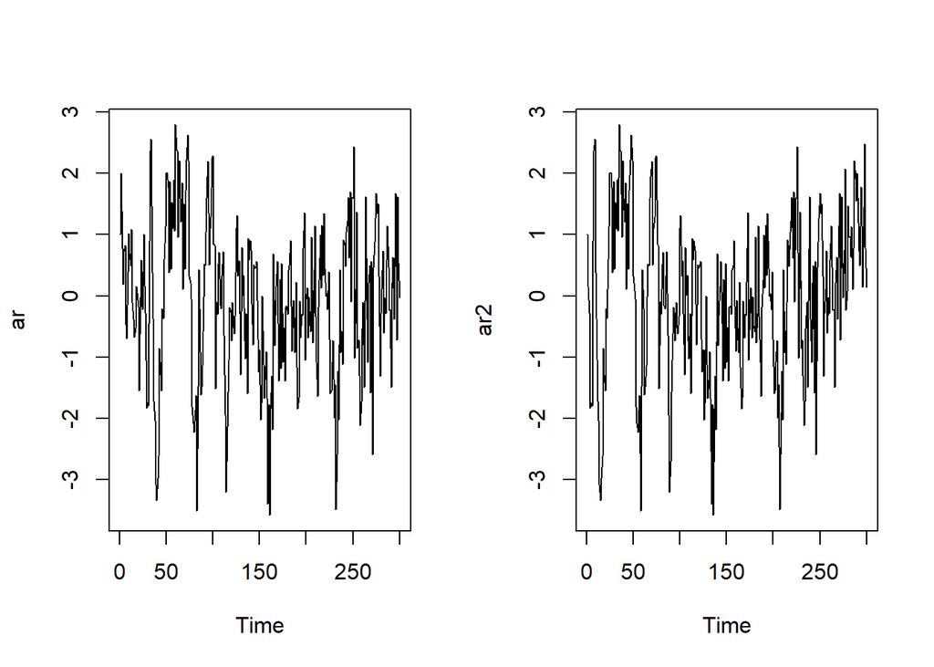

```r
par(mfrow = c(1,2))
ts.plot(ar)
ts.plot(ar2)
```

Berdasarkan plot time series tersebut terlihat bahwa data cenderung stasioner pada rataan

### Plot ACF

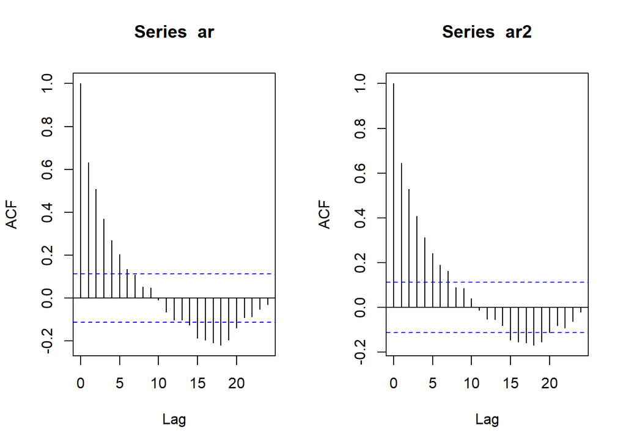

```r
par(mfrow = c(1,2))
acf(ar)
acf(ar2)
```

Berdasarkan plot ACF tersebut terlihat bahwa plot ACF cenderung *tails off* dan cenderung membentuk pola grafik sinus

### Plot PACF

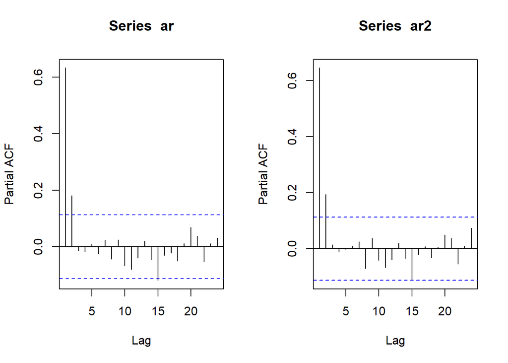

```r
par(mfrow =c(1,2))
pacf(ar)
pacf(ar2)
```

Berdasarkan plot PACF tersebut diketahui terdapat autorelasi

### Plot EACF

```r
TSA::eacf(ar)
```

```
## AR/MA
##   0 1 2 3 4 5 6 7 8 9 10 11 12 13
## 0 x x x x x x o o o o o  o  o  x
## 1 x o o o o o o o o o o  o  o  o
## 2 o o o o o o o o o o o  o  o  o
## 3 x o o o o o o o o o o  o  o  o
## 4 x x o o o o o o o o o  o  o  o
## 5 x x o o o o o o o o o  o  o  o
## 6 x x x x o o o o o o o  o  o  o
## 7 x x x o o o o o o o o  o  o  o
```

```r
TSA::eacf(ar2)
```

```
## AR/MA
##   0 1 2 3 4 5 6 7 8 9 10 11 12 13
## 0 x x x x x x x o o o o  o  o  o
## 1 x o o o o o o o o o o  o  o  o
## 2 o o o o o o o o o o o  o  o  o
## 3 x o o o o o o o o o o  o  o  o
## 4 x x o o o o o o o o o  o  o  o
## 5 x o x o o o o o o o o  o  o  o
## 6 x x o x o o o o o o o  o  o  o
## 7 x x o o x o o o o o o  o  o  o
```

### Scatterplot Antar Lag

#### Korelasi antara $Y_t$ dengan $Y_{t-1}$

```r
#Yt
yt_ar <- ar[-1]
head(yt_ar)
```

```
## [1]  2.0000000  0.7727971  0.1904166  0.7170913  0.8182680 -0.4690999
```

```r
#Yt-1
yt_1_ar <- ar[-300]
head(yt_1_ar)
```

```
## [1] 1.0000000 2.0000000 0.7727971 0.1904166 0.7170913 0.8182680
```

```r
#Yt
yt_ar2 <- ar2[-1]
head(yt_ar2)
```

```
## [1]  0.1570980 -0.2775442 -1.8357632 -1.7381776 -1.7928526  0.8909172
```

```r
#Yt-1
yt_1_ar2 <- ar2[-300]
head(yt_1_ar2)
```

```
## [1]  1.0027262  0.1570980 -0.2775442 -1.8357632 -1.7381776 -1.7928526
```

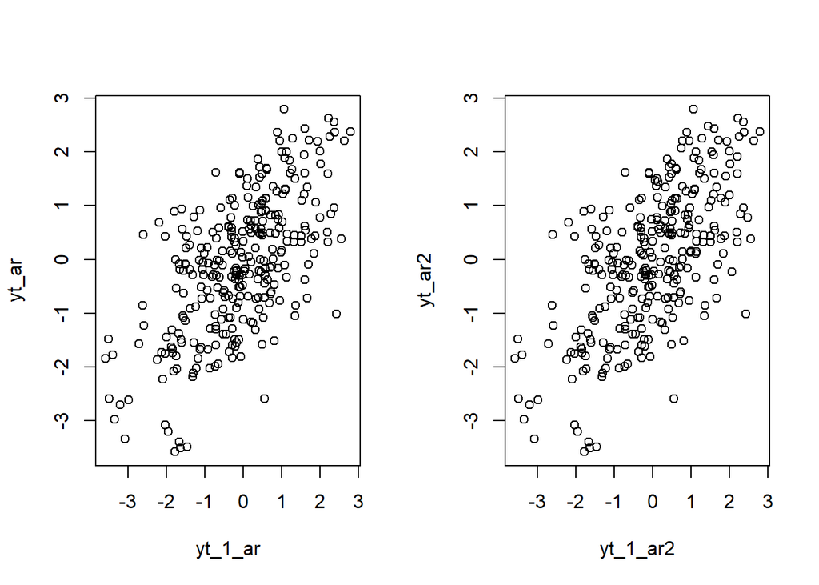

```r
par(mfrow = c(1,2))
plot(y=yt_ar,x=yt_1_ar)
plot(y=yt_ar2,x=yt_1_ar2)
```

```r
cor(yt_ar,yt_1_ar)
```

```
## [1] 0.6331071
```

```r
cor(yt_ar2,yt_1_ar2)
```

```
## [1] 0.6457861
```

#### Korelasi antara $Y_t$ dengan $Y_{t-2}$

```r
#Yt
yt2_ar <- ar[-c(1,2)]
head(yt2_ar)
```

```
## [1]  0.7727971  0.1904166  0.7170913  0.8182680 -0.4690999 -0.6933733
```

```r
#Yt-2
yt_2_ar <- ar[-c(299,300)]
head(yt_2_ar)
```

```
## [1] 1.0000000 2.0000000 0.7727971 0.1904166 0.7170913 0.8182680
```

```r
#Yt
yt2_ar2 <- ar[-c(1,2)]
head(yt2_ar)
```

```
## [1]  0.7727971  0.1904166  0.7170913  0.8182680 -0.4690999 -0.6933733
```

```r
#Yt-2
yt_2_ar2 <- ar[-c(299,300)]
head(yt_2_ar2)
```

```
## [1] 1.0000000 2.0000000 0.7727971 0.1904166 0.7170913 0.8182680
```

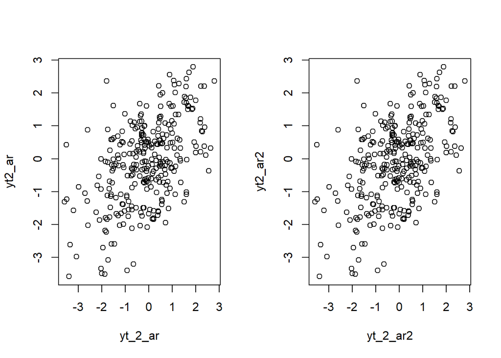

```r
par(mfrow = c(1,2))
plot(y=yt2_ar,x=yt_2_ar)
plot(y=yt2_ar2,x=yt_2_ar2)
```

```r
cor(yt2_ar,yt_2_ar)
```

```
## [1] 0.5118072
```

```r
cor(yt2_ar2,yt_2_ar2)
```

```
## [1] 0.5118072
```

#### Korelasi antara $Y_t$ dengan $Y_{t-3}$

```r
#Yt
yt3_ar <- ar[-c(1,2,3)]
head(yt3_ar)
```

```
## [1]  0.1904166  0.7170913  0.8182680 -0.4690999 -0.6933733  0.3964951
```

```r
#Yt-3
yt_3_ar <- ar[-c(288,299,300)]
head(yt_3_ar)
```

```
## [1] 1.0000000 2.0000000 0.7727971 0.1904166 0.7170913 0.8182680
```

```r
#Yt
yt3_ar2 <- ar[-c(1,2,3)]
head(yt3_ar)
```

```
## [1]  0.1904166  0.7170913  0.8182680 -0.4690999 -0.6933733  0.3964951
```

```r
#Yt-2
yt_3_ar2 <- ar[-c(298,299,300)]
head(yt_3_ar2)
```

```
## [1] 1.0000000 2.0000000 0.7727971 0.1904166 0.7170913 0.8182680
```

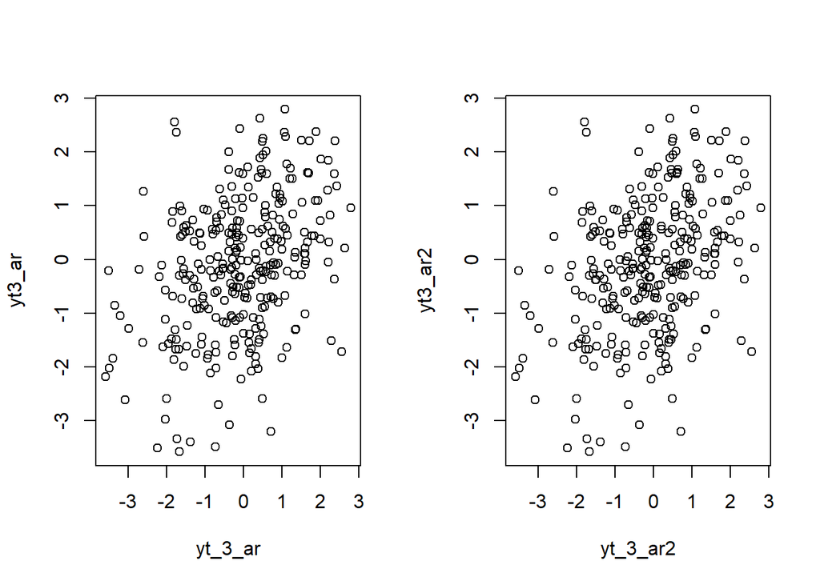

```r
par(mfrow = c(1,2))
plot(y=yt3_ar,x=yt_3_ar)
plot(y=yt3_ar2,x=yt_3_ar2)
```

```r
cor(yt3_ar,yt_3_ar)
```

```
## [1] 0.3680484
```

```r
cor(yt3_ar2,yt_3_ar2)
```

```
## [1] 0.3733838
```

## Pembangkitan ARMA (2,2)

```r
set.seed(039)
coefs <- c(0.6, 0.4, 0.5,0.2)
e <- c(1, 2, 3, 4)

coefs %*% e
```

```
##      [,1]
## [1,]  3.7
```

Atau, dapat dilakukan perkalian *elementwise* yang dijumlahkan:

```r
coefs * e
```

```
## [1] 0.6 0.8 1.5 0.8
```

```r
sum(coefs * e)
```

```
## [1] 3.7
```

Dari prinsip ini, dapat dibuat fungsi umum untuk membangkitkan data ARMA. Input dari fungsi adalah jumlah data yang hendak dibangkitkan, koefisien MA, dan koefisien AR

```r
arma.sim <- function(n, macoef, arcoef){
  manum <- length(macoef)
  arnum <- length(arcoef)
  stopifnot(manum < n & arnum < n)

  wn <- rnorm(n, sd = 0.5)
  init <- max(manum, arnum)

  arma <- wn[1:init]
  for(i in {init+1}:n){
   mastart <- i - manum
   maend <- i-1
   arstart <- i - arnum
   arend <- i-1
   arma[i] <- sum(arcoef * arma[arstart:arend]) + sum(macoef * wn[mastart:maend])  + wn[i]
   }
  return(arma)
}
```

```r
arma <- arma.sim(300, c(0.4,0.6), c(0.5,0.2))
head(arma)
```

```
## [1] -0.09278286 -0.61462133 -0.78880311 -1.13707166 -0.65238927 -0.46719351
```

```r
set.seed(039)
n = length(wn)
phi1 = 0.5
phi2 = 0.2
theta1 = 0.4
theta2 = 0.6

y.arma=c(1:n)
for (i in 3:n){y.arma[i] = phi1*y.arma[i-1] + theta1*wn[i-1] + phi2*y.arma[i-2] + theta2*wn[i-2] + wn[i]}
head(y.arma)
```

```
## [1]  1.0000000  2.0000000  0.1697606 -1.0195284 -0.5032031 -0.2045280
```

Pembangkitan ARMA(p,q) juga dapat dilakukan dengan fungsi `arima.sim` sebagai berikut.

```r
arma22 <- arima.sim(list(order=c(2,0,2), ar = c(0.5,0.2), ma = c(0.4,0.6)), n=300)
head(arma22)
```

```
## [1]  0.3878584 -1.8518149 -2.6384702 -3.5891705 -0.8688170  1.6492822
```

### Plot Time Series

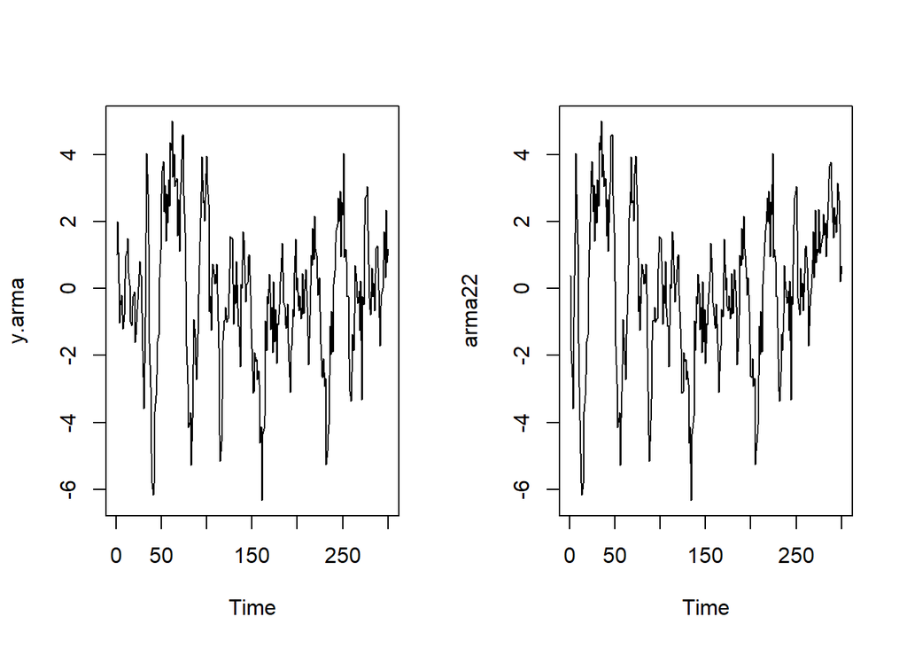

```r
par(mfrow = c(1, 2))
ts.plot(y.arma)
ts.plot(arma22)
```

### Plot ACF

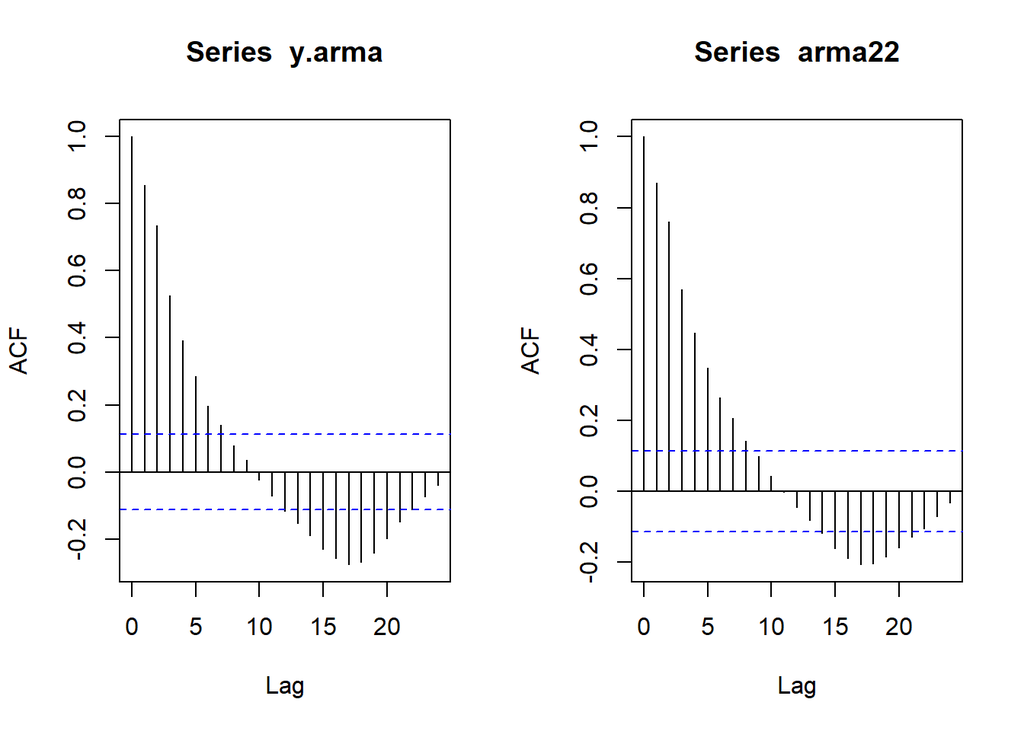

```r
par(mfrow = c(1, 2))
acf(y.arma)
acf(arma22)
```

Berdasarkan plot AFC tersebut, diketahui bahwa dalam model tersebut terdapat autokorelasi

### Plot PACF

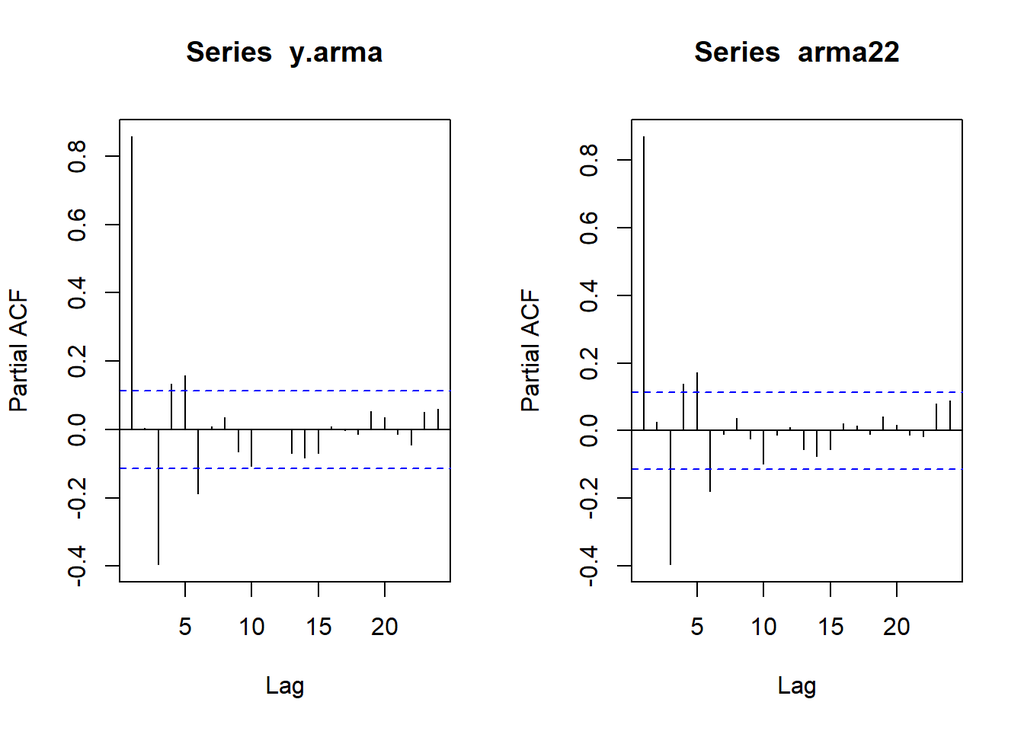

```r
par(mfrow = c(1, 2))
pacf(y.arma)
pacf(arma22)
```

### Plot EACF

```r
TSA::eacf(y.arma)
```

```
## AR/MA
##   0 1 2 3 4 5 6 7 8 9 10 11 12 13
## 0 x x x x x x x o o o o  o  x  x
## 1 o x o o o o o o o o o  o  o  o
## 2 o x o o o o o o o o o  o  o  o
## 3 x x o x o o o o o o o  o  o  o
## 4 x x o x o o o o o o o  o  o  o
## 5 x x o x o o o o o o o  o  o  o
## 6 o x x x o o o o o o o  o  o  o
## 7 x o o x o o x x o o o  o  o  o
```

```r
TSA::eacf(arma22)
```

```
## AR/MA
##   0 1 2 3 4 5 6 7 8 9 10 11 12 13
## 0 x x x x x x x x o o o  o  o  x
## 1 o x o o o o o o o o o  o  o  o
## 2 o x o o o o o o x o o  o  o  o
## 3 x x o o o o o o o o o  o  o  o
## 4 x x o x o o o o o o o  o  o  o
## 5 x x o x o o o o o o o  o  o  o
## 6 o x x x x o o o o o o  o  o  o
## 7 x o o x o o o o o o o  o  o  o
```

### Scatterplot Antar Lag

#### Korelasi antara $Y_t$ dengan $Y_{t-1}$

```r
#Yt
yt_arma <- arma22[-1]
head(yt_arma)
```

```
## [1] -1.851815 -2.638470 -3.589171 -0.868817  1.649282  4.041441
```

```r
#Yt-1
yt_1_arma <- arma22[-300]
head(yt_1_arma)
```

```
## [1]  0.3878584 -1.8518149 -2.6384702 -3.5891705 -0.8688170  1.6492822
```

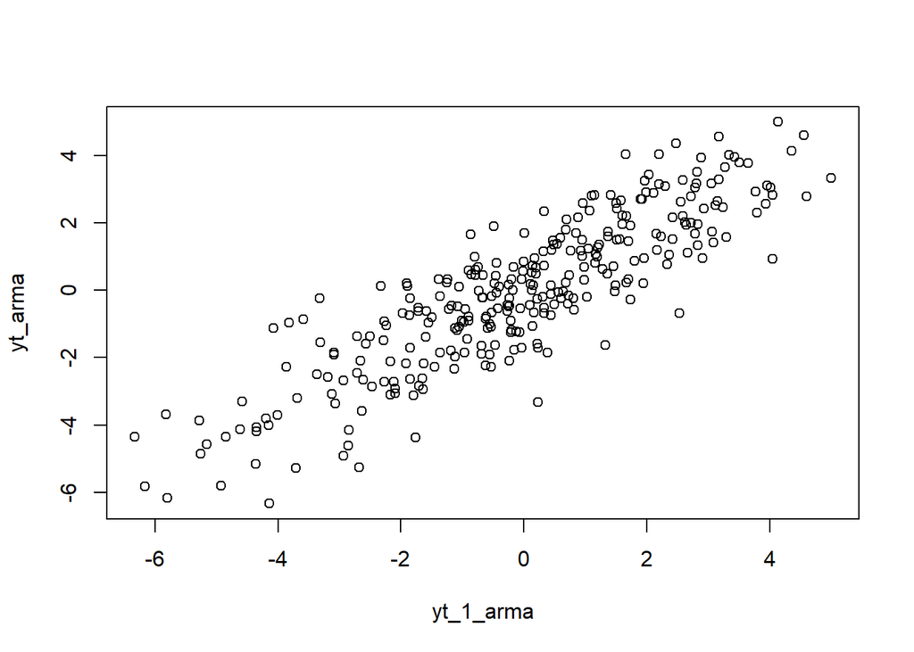

```r
plot(y=yt_arma,x=yt_1_arma)
```

```r
cor(yt_arma,yt_1_arma)
```

```
## [1] 0.8692938
```

#### Korelasi antara $Y_t$ dengan $Y_{t-2}$

```r
#Yt
yt2_arma <- arma22[-c(1,2)]
head(yt2_arma)
```

```
## [1] -2.638470 -3.589171 -0.868817  1.649282  4.041441  2.824143
```

```r
#Yt-2
yt_2_arma <- arma22[-c(299,300)]
head(yt_2_arma)
```

```
## [1]  0.3878584 -1.8518149 -2.6384702 -3.5891705 -0.8688170  1.6492822
```

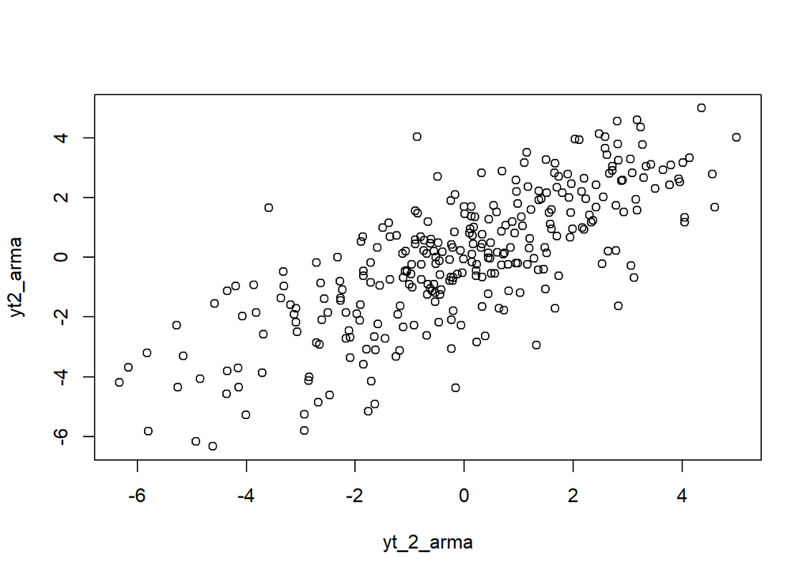

```r
plot(y=yt2_arma,x=yt_2_arma)
```

```r
cor(yt2_arma,yt_2_arma)
```

```
## [1] 0.7624657
```

#### Korelasi antara $Y_t$ dengan $Y_{t-3}$

```r
#Yt
yt3_arma <- arma22[-c(1,2,3)]
head(yt3_arma)
```

```
## [1] -3.589171 -0.868817  1.649282  4.041441  2.824143  1.324111
```

```r
#Yt-2
yt_3_arma <- arma22[-c(298,299,300)]
head(yt_3_arma)
```

```
## [1]  0.3878584 -1.8518149 -2.6384702 -3.5891705 -0.8688170  1.6492822
```

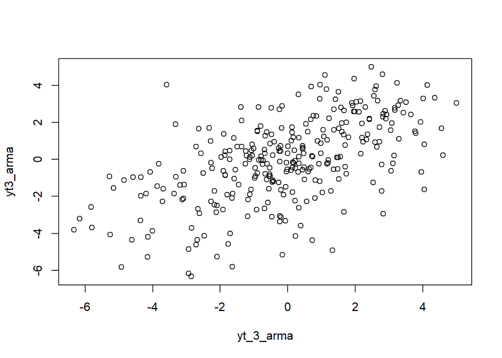

```r
plot(y=yt3_arma,x=yt_3_arma)
```

```r
cor(yt3_arma,yt_3_arma)
```

```
## [1] 0.5730679
```